# Shift Share

Joe Yuke

12/31/2020

Shift-Share analysis is a technique used by urban planners, regional analysts, and economic developers to identify the sources of regional economic growth. Assuming job growth in Santa Barbara County can be explained by three components: National Share, Industry Mix, and Regional Shift, we can compare different sectors of the economy and identify competitive industries as the ones that outperform their counterpart at the state/national level. This information can then be used to inform public investment decisions and economic development policy.

In 2019, Santa Barbara County added 4,249 jobs, achieving a 2.5% increase across all industries. This is a significant change from the prior year’s growth of 2,715 jobs. Notably, employment success was driven by the Professional, Scientific & Technical Services sector which grew by 633 jobs; the Health Care & Social Assistance sector’s gain of 647 jobs; and Agriculture’s increase of 1,227 jobs.  
At the state and national levels, there were also increases in the total number of jobs but at less pronounced rates. California added 251,568 jobs in 2019, representing a 1.7% increase from the previous year, and the US added 1,806,905 jobs, growing by 1.5%.

## Employment by Industry Sector

2018 - 2019

SB

CA

US

2018

2019

%Change

2018

2019

%Change

2018

2019

%Change

Agriculture

22812

24039

5.4

423254

423250

0

1263676

1263160

0

Construction

8796

8860

0.7

860278

885668

3

7225870

7451476

3.1

Manufacturing

12811

12912

0.8

1320068

1322455

0.2

12647900

12776157

1

Wholesale Trade

5100

5069

-0.6

701000

694227

-1

5855477

5883948

0.5

Retail Trade

18547

18549

0

1683999

1658883

-1.5

15791102

15602881

-1.2

Transportation & Warehousing

3061

3181

3.9

591585

632568

6.9

5208134

5491748

5.4

Information

4013

3974

-1

525771

550084

4.6

2815363

2849185

1.2

Finance & Insurance

3671

3719

1.3

541315

538869

-0.5

5953548

6027485

1.2

Real Estate

3013

3096

2.8

294581

302960

2.8

2233761

2292359

2.6

Prof. & Technical Services

11038

11671

5.7

1286277

1333978

3.7

9288519

9542312

2.7

Management

2723

2825

3.7

252952

255434

1

2347219

2407183

2.6

Admin & Waste Services

8741

9011

3.1

1128609

1134025

0.5

9236298

9284487

0.5

Health Care & Social Assistance

24245

24892

2.7

2324828

2400363

3.2

19741426

20184056

2.2

Arts, Entertainment, & Recreation

3582

3778

5.5

316124

329778

4.3

2362663

2426459

2.7

Accommodation & Food Services

24519

24741

0.9

1672626

1705141

1.9

13834194

14030794

1.4

Total Private Employment

166926

171175

2.5

14876010

15127578

1.7

124551838

126358743

1.5

Agriculture, Health Care, and the Accommodation & Food sector have consistently been Santa Barbara County’s largest industries in terms of employment. Over the past 10 years, all three have experienced fairly steady growth as well. However, to assess industry performance, we should look beyond the raw employment numbers.

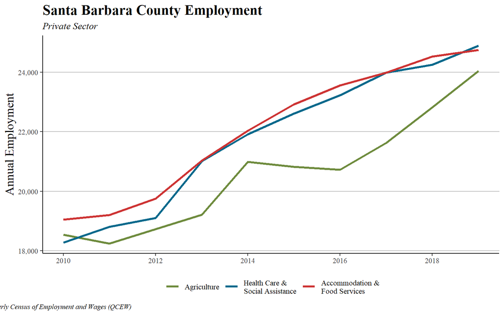

Shift-Share analysis can explain how much of the job growth within an industry should be attributed to local conditions. As an example, Retail Trade, the county’s fourth largest industry, added a mere 2 jobs in 2019. In fact, this small increase is a competitive performance compared to the national and state retail industries. The “National Share” calculation yields 18,816 which represents the number of jobs that would exist in the local retail industry had it grown at the same rate as the whole US economy. In other words, how much job growth should have been expected according to the national business cycle. “Industry Mix” assumes changes in employment consistent with the growth of the national retail industry. The US-SB analysis identifies a negative Industry Mix of -490. This is because the Retail Trade sector performed poorly at the national level, declining by 1.2% in 2019. Finally, the “Regional Shift” identifies leading industries by finding the differential between the local and national rates of growth and using it as a multiplier for the previous year’s job numbers. The Retail Trade sector for Santa Barbara County achieved a regional shift of 223 jobs, which represents 1.2% of local retail jobs. Industries that have positive Regional Shift scores are deemed competitive according to Shift-Share analysis. Adding all three calculations together yields the true employment numbers for the industry of interest in 2019. For this report, we also run the analysis substituting California’s employment numbers for the US’s statistics. Interestingly, Santa Barbara’s Retail industry performed even stronger relative to the state of California.  
The Professional, Scientific, and Technical Services industry, which encompasses lawyers, engineers, researchers etc., achieved a relatively high Regional Shift of 331, or 2.8% of employment in that industry. This sector has been increasing slightly since 2016 but has largely remained consistent for the past 10 years.

## Shift Share by Industry Sector

Santa Barbara: 2018 - 2019

US-SB

CA-SB

National Share

Industry Mix

Regional Share

State Share

Industry Mix

Regional Share

Agriculture

23143

-340

1236

23198

-386

1227

Construction

8924

147

-211

8945

111

-196

Manufacturing

12997

-56

-29

13028

-194

78

Wholesale Trade

5174

-49

-56

5186

-135

18

Retail Trade

18816

-490

223

18861

-591

279

Transportation & Warehousing

3105

123

-47

3113

160

-92

Information

4071

-10

-87

4081

118

-225

Finance & Insurance

3724

-7

2

3733

-79

65

Real Estate

3057

35

4

3064

35

-3

Prof. & Technical Services

11198

142

331

11225

222

224

Management

2763

30

32

2769

-19

75

Admin & Waste Services

8868

-81

224

8889

-106

228

Health Care & Social Assistance

24597

192

103

24655

378

-141

Arts, Entertainment, & Recreation

3634

45

99

3643

94

41

Accommodation & Food Services

24875

-8

-126

24934

62

-255

Out of the County’s top three industries, Agriculture was the only one to realize a positive Regional Shift across both US and CA calculations. In the US-SB calculation, the Regional Shift was 1,236, or 5.1% of agricultural employment, making it the most competitive industry for Santa Barbara in 2019. Statewide and nationally, Agriculture represents a much smaller portion of the labor force and is typically outpaced in terms of growth when compared to Santa Barbara county. Health Care saw a modest increase of 647 jobs, but relative to the changes in California’s Health Care employment, this does not represent significant growth. Finally, the Accommodation and Food Services industry added only 222 jobs and underperformed compared to the national and particularly the state level. This is indicated in the much more negative Regional Shift for the CA-SB analysis.

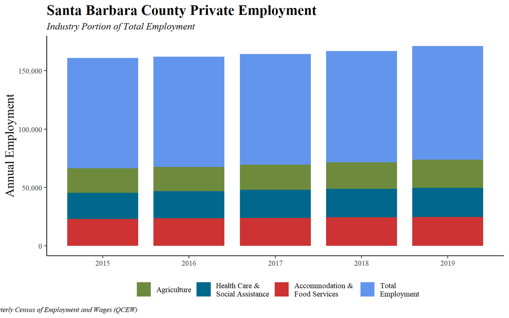

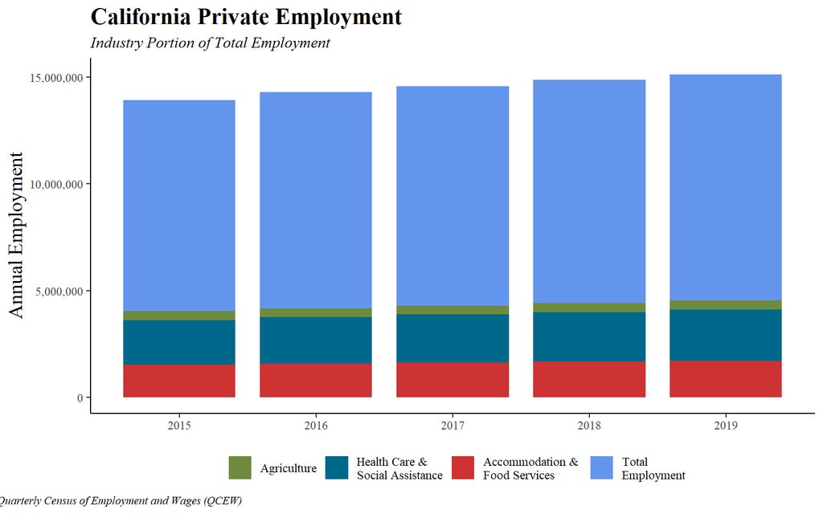

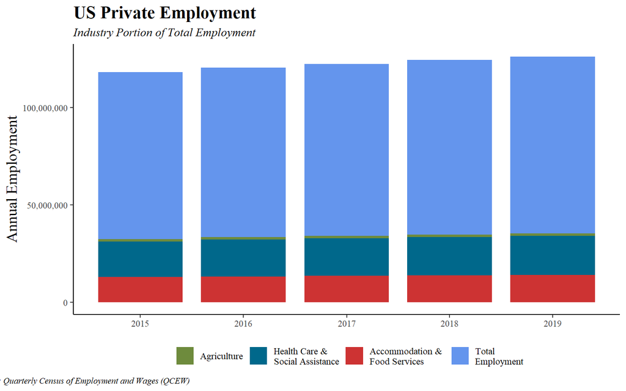